# Predicting Credit Client’s Payment Abilities

# 1.Introduction

This notebook will examine default credit data. I try to build a predictive model to determine the payment status of the client. Hopefully, by examining the characteristics of the client we can predict whether they will have difficulties in payment or will repay the credit on time.

# 2.Retrieving Data

There are 7 different sources of data, but this time I will only use application_train data as the data source for analysis. The data is still manageable to work with my current tool.

```r
library(readr) #package reading data
library(tidyverse) #package for table manipulation
library(randomForest)
library(caret)
library(DataExplorer)
require(xgboost)
library(ROCR)
library(pROC)


#Read Data
data <- read.csv("application_train.csv")
```

# 3.Glimpse of Data

In additon of having a firm theory of the risk, examining our data will help us enhancing our hypothesis. We can use summary() to examine the mean,median, max, min, etc of the data.

```r
head(data) #showing the first five of the records
```

|  | SK_ID_CURR | TARGET | NAME_CONTRACT_TYPE | CODE_GENDER | FLAG_OWN_CAR | FLAG_OWN_REALTY | CNT_CHILDREN | AMT_INCOME_TOTAL | AMT_CREDIT | AMT_ANNUITY | AMT_GOODS_PRICE | NAME_TYPE_SUITE | NAME_INCOME_TYPE | NAME_EDUCATION_TYPE | NAME_FAMILY_STATUS | NAME_HOUSING_TYPE | REGION_POPULATION_RELATIVE | DAYS_BIRTH | DAYS_EMPLOYED | DAYS_REGISTRATION | DAYS_ID_PUBLISH | OWN_CAR_AGE | FLAG_MOBIL | FLAG_EMP_PHONE | FLAG_WORK_PHONE | FLAG_CONT_MOBILE | FLAG_PHONE | FLAG_EMAIL | OCCUPATION_TYPE | … |
| --- | --- | --- | --- | --- | --- | --- | --- | --- | --- | --- | --- | --- | --- | --- | --- | --- | --- | --- | --- | --- | --- | --- | --- | --- | --- | --- | --- | --- | --- | --- |
| 1 | 100002 | 1 | Cash loans | M | N | Y | 0 | 202500 | 406597.5 | 24700.5 | 351000 | Unaccompanied | Working | Secondary / secondary special | Single / not married | House / apartment | 0.018801 | -9461 | -637 | -3648 | -2120 | NA | 1 | 1 | 0 | 1 | 1 | 0 | Laborers | … |
| 2 | 100003 | 0 | Cash loans | F | N | N | 0 | 270000 | 1293502.5 | 35698.5 | 1129500 | Family | State servant | Higher education | Married | House / apartment | 0.003541 | -16765 | -1188 | -1186 | -291 | NA | 1 | 1 | 0 | 1 | 1 | 0 | Core staff | … |
| 3 | 100004 | 0 | Revolving loans | M | Y | Y | 0 | 67500 | 135000.0 | 6750.0 | 135000 | Unaccompanied | Working | Secondary / secondary special | Single / not married | House / apartment | 0.010032 | -19046 | -225 | -4260 | -2531 | 26 | 1 | 1 | 1 | 1 | 1 | 0 | Laborers | … |
| 4 | 100006 | 0 | Cash loans | F | N | Y | 0 | 135000 | 312682.5 | 29686.5 | 297000 | Unaccompanied | Working | Secondary / secondary special | Civil marriage | House / apartment | 0.008019 | -19005 | -3039 | -9833 | -2437 | NA | 1 | 1 | 0 | 1 | 0 | 0 | Laborers | … |
| 5 | 100007 | 0 | Cash loans | M | N | Y | 0 | 121500 | 513000.0 | 21865.5 | 513000 | Unaccompanied | Working | Secondary / secondary special | Single / not married | House / apartment | 0.028663 | -19932 | -3038 | -4311 | -3458 | NA | 1 | 1 | 0 | 1 | 0 | 0 | Core staff | … |
| 6 | 100008 | 0 | Cash loans | M | N | Y | 0 | 99000 | 490495.5 | 27517.5 | 454500 | Spouse, partner | State servant | Secondary / secondary special | Married | House / apartment | 0.035792 | -16941 | -1588 | -4970 | -477 | NA | 1 | 1 | 1 | 1 | 1 | 0 | Laborers | … |

```r
str(data) #checking the type variables
```

```
## 'data.frame':    307511 obs. of  122 variables:
##  $ SK_ID_CURR                  : int  100002 100003 100004 100006 100007 100008 100009 100010 100011 100012 ...
##  $ TARGET                      : int  1 0 0 0 0 0 0 0 0 0 ...
##  $ NAME_CONTRACT_TYPE          : Factor w/ 2 levels "Cash loans","Revolving loans": 1 1 2 1 1 1 1 1 1 2 ...
##  $ CODE_GENDER                 : Factor w/ 3 levels "F","M","XNA": 2 1 2 1 2 2 1 2 1 2 ...
##  $ FLAG_OWN_CAR                : Factor w/ 2 levels "N","Y": 1 1 2 1 1 1 2 2 1 1 ...
##  $ FLAG_OWN_REALTY             : Factor w/ 2 levels "N","Y": 2 1 2 2 2 2 2 2 2 2 ...
##  $ CNT_CHILDREN                : int  0 0 0 0 0 0 1 0 0 0 ...
##  $ AMT_INCOME_TOTAL            : num  202500 270000 67500 135000 121500 ...
##  $ AMT_CREDIT                  : num  406598 1293503 135000 312683 513000 ...
##  $ AMT_ANNUITY                 : num  24701 35699 6750 29687 21866 ...
##  $ AMT_GOODS_PRICE             : num  351000 1129500 135000 297000 513000 ...
##  $ NAME_TYPE_SUITE             : Factor w/ 8 levels "","Children",..: 8 3 8 8 8 7 8 8 2 8 ...
##  $ NAME_INCOME_TYPE            : Factor w/ 8 levels "Businessman",..: 8 5 8 8 8 5 2 5 4 8 ...
##  $ NAME_EDUCATION_TYPE         : Factor w/ 5 levels "Academic degree",..: 5 2 5 5 5 5 2 2 5 5 ...
```

[output cut: 86 more lines]

# 4.Checking Missing Data

Missing data can produce noise especially if it can change the distribution of the data. I will generate how many observations that are missing in each variables using a handy r package called DataExplorer.

```r
a1 <- as.data.frame(colSums(is.na(data)))
b1 <- round (as.data.frame(colMeans(is.na(data))*100),digits=2)
miss <- data.frame(cbind(setNames(a1,c("count")),
                              setNames(b1,c("percentage"))))
remove(a1,b1)
print(miss)
```

```
##                               count percentage
## SK_ID_CURR                        0       0.00
## TARGET                            0       0.00
## NAME_CONTRACT_TYPE                0       0.00
## CODE_GENDER                       0       0.00
## FLAG_OWN_CAR                      0       0.00
## FLAG_OWN_REALTY                   0       0.00
## CNT_CHILDREN                      0       0.00
## AMT_INCOME_TOTAL                  0       0.00
## AMT_CREDIT                        0       0.00
## AMT_ANNUITY                      12       0.00
## AMT_GOODS_PRICE                 278       0.09
## NAME_TYPE_SUITE                   0       0.00
## NAME_INCOME_TYPE                  0       0.00
## NAME_EDUCATION_TYPE               0       0.00
## NAME_FAMILY_STATUS                0       0.00
## NAME_HOUSING_TYPE                 0       0.00
## REGION_POPULATION_RELATIVE        0       0.00
## DAYS_BIRTH                        0       0.00
## DAYS_EMPLOYED                     0       0.00
## DAYS_REGISTRATION                 0       0.00
## DAYS_ID_PUBLISH                   0       0.00
## OWN_CAR_AGE                  202929      65.99
## FLAG_MOBIL                        0       0.00
## FLAG_EMP_PHONE                    0       0.00
## FLAG_WORK_PHONE                   0       0.00
## FLAG_CONT_MOBILE                  0       0.00
## FLAG_PHONE                        0       0.00
## FLAG_EMAIL                        0       0.00
## OCCUPATION_TYPE                   0       0.00
## CNT_FAM_MEMBERS                   2       0.00
## REGION_RATING_CLIENT              0       0.00
## REGION_RATING_CLIENT_W_CITY       0       0.00
## WEEKDAY_APPR_PROCESS_START        0       0.00
## HOUR_APPR_PROCESS_START           0       0.00
## REG_REGION_NOT_LIVE_REGION        0       0.00
## REG_REGION_NOT_WORK_REGION        0       0.00
## LIVE_REGION_NOT_WORK_REGION       0       0.00
## REG_CITY_NOT_LIVE_CITY            0       0.00
## REG_CITY_NOT_WORK_CITY            0       0.00
```

[output cut: 68 more lines]

```
## FLAG_DOCUMENT_13                  0       0.00
## FLAG_DOCUMENT_14                  0       0.00
## FLAG_DOCUMENT_15                  0       0.00
## FLAG_DOCUMENT_16                  0       0.00
## FLAG_DOCUMENT_17                  0       0.00
## FLAG_DOCUMENT_18                  0       0.00
## FLAG_DOCUMENT_19                  0       0.00
## FLAG_DOCUMENT_20                  0       0.00
## FLAG_DOCUMENT_21                  0       0.00
## AMT_REQ_CREDIT_BUREAU_HOUR    41519      13.50
## AMT_REQ_CREDIT_BUREAU_DAY     41519      13.50
## AMT_REQ_CREDIT_BUREAU_WEEK    41519      13.50
## AMT_REQ_CREDIT_BUREAU_MON     41519      13.50
## AMT_REQ_CREDIT_BUREAU_QRT     41519      13.50
## AMT_REQ_CREDIT_BUREAU_YEAR    41519      13.50
```

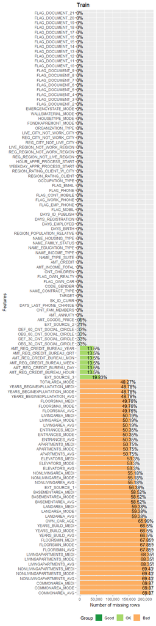

```r
#plot_missing(train, title="missing values")
#I run the plot seperately and resize it to make it easier to look
```

# 5.Recoding and Anomaly Data

There are some categorical variables that need to be recoded since they are still in string type. By recoding them, they are ready to be analysed as categorical data (nominal and ordinal). I also check whether there is an anomlay in the data or not. DAYS_BIRTH has negative values which indicate an anomaly (not make sense), but I can get the client’s age from that variable by transforming the data (dividing with -365).

```r
#Recoding Data
dmy1 <- dummyVars("~NAME_INCOME_TYPE", data, fullRank = T)
trsf1 <- data.frame(predict(dmy1, newdata = data))

dmy2 <- dummyVars("~OCCUPATION_TYPE", data, fullRank = T)
trsf2 <- data.frame(predict(dmy2, newdata = data))

dmy3 <- dummyVars("~NAME_EDUCATION_TYPE", data, fullRank = T)
trsf3 <- data.frame(predict(dmy3, newdata = data))

data <- cbind(data,trsf1,trsf2,trsf3,fill=T)

remove(dmy1,dmy2,dmy3,trsf1,trsf2,trsf3) #cleaning object

head(data)
```

|  | SK_ID_CURR | TARGET | NAME_CONTRACT_TYPE | CODE_GENDER | FLAG_OWN_CAR | FLAG_OWN_REALTY | CNT_CHILDREN | AMT_INCOME_TOTAL | AMT_CREDIT | AMT_ANNUITY | AMT_GOODS_PRICE | NAME_TYPE_SUITE | NAME_INCOME_TYPE | NAME_EDUCATION_TYPE | NAME_FAMILY_STATUS | NAME_HOUSING_TYPE | REGION_POPULATION_RELATIVE | DAYS_BIRTH | DAYS_EMPLOYED | DAYS_REGISTRATION | DAYS_ID_PUBLISH | OWN_CAR_AGE | FLAG_MOBIL | FLAG_EMP_PHONE | FLAG_WORK_PHONE | FLAG_CONT_MOBILE | FLAG_PHONE | FLAG_EMAIL | OCCUPATION_TYPE | … |
| --- | --- | --- | --- | --- | --- | --- | --- | --- | --- | --- | --- | --- | --- | --- | --- | --- | --- | --- | --- | --- | --- | --- | --- | --- | --- | --- | --- | --- | --- | --- |
| 1 | 100002 | 1 | Cash loans | M | N | Y | 0 | 202500 | 406597.5 | 24700.5 | 351000 | Unaccompanied | Working | Secondary / secondary special | Single / not married | House / apartment | 0.018801 | -9461 | -637 | -3648 | -2120 | NA | 1 | 1 | 0 | 1 | 1 | 0 | Laborers | … |
| 2 | 100003 | 0 | Cash loans | F | N | N | 0 | 270000 | 1293502.5 | 35698.5 | 1129500 | Family | State servant | Higher education | Married | House / apartment | 0.003541 | -16765 | -1188 | -1186 | -291 | NA | 1 | 1 | 0 | 1 | 1 | 0 | Core staff | … |
| 3 | 100004 | 0 | Revolving loans | M | Y | Y | 0 | 67500 | 135000.0 | 6750.0 | 135000 | Unaccompanied | Working | Secondary / secondary special | Single / not married | House / apartment | 0.010032 | -19046 | -225 | -4260 | -2531 | 26 | 1 | 1 | 1 | 1 | 1 | 0 | Laborers | … |
| 4 | 100006 | 0 | Cash loans | F | N | Y | 0 | 135000 | 312682.5 | 29686.5 | 297000 | Unaccompanied | Working | Secondary / secondary special | Civil marriage | House / apartment | 0.008019 | -19005 | -3039 | -9833 | -2437 | NA | 1 | 1 | 0 | 1 | 0 | 0 | Laborers | … |
| 5 | 100007 | 0 | Cash loans | M | N | Y | 0 | 121500 | 513000.0 | 21865.5 | 513000 | Unaccompanied | Working | Secondary / secondary special | Single / not married | House / apartment | 0.028663 | -19932 | -3038 | -4311 | -3458 | NA | 1 | 1 | 0 | 1 | 0 | 0 | Core staff | … |
| 6 | 100008 | 0 | Cash loans | M | N | Y | 0 | 99000 | 490495.5 | 27517.5 | 454500 | Spouse, partner | State servant | Secondary / secondary special | Married | House / apartment | 0.035792 | -16941 | -1588 | -4970 | -477 | NA | 1 | 1 | 1 | 1 | 1 | 0 | Laborers | … |

```r
#Correcting Anomaly in Days_BIRTH
data$DAYS_BIRTH <- data$DAYS_BIRTH/-365
```

# 6.DATA Exploration

This time I use Tableau to help me doing Data Explanatory Analysis, since my current tool can’t handle to run the data. It is very computer excessive.

[Link_Tableau](https://public.tableau.com/views/HCI2/HomeCredit?:embed=y&:display_count=yes)

[interactive chart not shown]

# 7.Correlation

correlation is used to check linear relationship among variables. It is also a good start before making the model, we will know the direction of the relationship. It could be the first signal whether our hypothesis is correct or not.

```r
library(reshape2)
cormat <- as.data.frame(cor(data[,c("TARGET","AMT_ANNUITY","AMT_CREDIT","AMT_GOODS_PRICE","EXT_SOURCE_1",
  "EXT_SOURCE_2","EXT_SOURCE_3","NAME_EDUCATION_TYPE.Higher.education",
  "NAME_EDUCATION_TYPE.Incomplete.higher","DAYS_BIRTH",
  "NAME_EDUCATION_TYPE.Lower.secondary",
  "NAME_INCOME_TYPE.Maternity.leave",
  "NAME_INCOME_TYPE.Pensioner",
  "NAME_INCOME_TYPE.Student","NAME_INCOME_TYPE.Unemployed",
  "NAME_INCOME_TYPE.Working","OCCUPATION_TYPE.Accountants",
  "OCCUPATION_TYPE.Cleaning.staff",
  "OCCUPATION_TYPE.High.skill.tech.staff",
  "OCCUPATION_TYPE.IT.staff","OCCUPATION_TYPE.Laborers",
  "OCCUPATION_TYPE.Low.skill.Laborers","OCCUPATION_TYPE.Managers",
  "OCCUPATION_TYPE.Realty.agents","OCCUPATION_TYPE.Sales.staff",
  "OCCUPATION_TYPE.Secretaries","OCCUPATION_TYPE.Security.staff",
  "OCCUPATION_TYPE.Waiters.barmen.staff")], method="spearman",
  use="complete"))

#Ideally, we should check all the variables relationships. But again, it is very computer excessive

cormat
```

|  | TARGET | AMT_ANNUITY | AMT_CREDIT | AMT_GOODS_PRICE | EXT_SOURCE_1 | EXT_SOURCE_2 | EXT_SOURCE_3 | NAME_EDUCATION_TYPE.Higher.education | NAME_EDUCATION_TYPE.Incomplete.higher | DAYS_BIRTH | NAME_EDUCATION_TYPE.Lower.secondary | NAME_INCOME_TYPE.Maternity.leave | NAME_INCOME_TYPE.Pensioner | NAME_INCOME_TYPE.Student | NAME_INCOME_TYPE.Unemployed | NAME_INCOME_TYPE.Working | OCCUPATION_TYPE.Accountants | OCCUPATION_TYPE.Cleaning.staff | OCCUPATION_TYPE.High.skill.tech.staff | OCCUPATION_TYPE.IT.staff | OCCUPATION_TYPE.Laborers | OCCUPATION_TYPE.Low.skill.Laborers | OCCUPATION_TYPE.Managers | OCCUPATION_TYPE.Realty.agents | OCCUPATION_TYPE.Sales.staff | OCCUPATION_TYPE.Secretaries | OCCUPATION_TYPE.Security.staff | OCCUPATION_TYPE.Waiters.barmen.staff |
| --- | --- | --- | --- | --- | --- | --- | --- | --- | --- | --- | --- | --- | --- | --- | --- | --- | --- | --- | --- | --- | --- | --- | --- | --- | --- | --- | --- | --- |
| TARGET | 1.0000000000 | 0.0020828796 | -0.0181034417 | -0.0303900817 | -0.1500661496 | -0.132212666 | -0.162259125 | -0.059266592 | 0.0058862496 | -0.067416197 | 0.0103757639 | NA | -0.0283060261 | -2.399165e-03 | -8.482058e-04 | 0.044359255 | -0.0235191962 | 0.0084188586 | -0.014231991 | -0.0012628014 | 0.036241373 | 0.0217004806 | -0.0173251374 | 0.0009450980 | 0.021170294 | -0.0031549104 | 0.013444141 | 0.0111909916 |
| AMT_ANNUITY | 0.0020828796 | 1.0000000000 | 0.8283398990 | 0.8250641706 | 0.1024051977 | 0.118156162 | 0.023268025 | 0.113287645 | -0.0064051852 | 0.078493197 | -0.0214927663 | NA | -0.0625629782 | -5.312066e-04 | -3.651917e-03 | -0.072044808 | 0.0458994381 | -0.0313161019 | 0.009744552 | -0.0015944918 | -0.035492869 | -0.0185475264 | 0.1259601808 | 0.0141637485 | -0.038453353 | -0.0074989333 | -0.017262144 | -0.0108384387 |
| AMT_CREDIT | -0.0181034417 | 0.8283398990 | 1.0000000000 | 0.9852257162 | 0.1513825321 | 0.124118321 | 0.036422710 | 0.103774604 | -0.0234613780 | 0.148343924 | -0.0178188211 | NA | -0.0229929154 | -1.699580e-03 | -2.895523e-03 | -0.082785214 | 0.0470763957 | -0.0230871162 | 0.012889843 | -0.0003786019 | -0.048712265 | -0.0244693638 | 0.1095428513 | 0.0063428624 | -0.044131150 | -0.0065312317 | -0.013208111 | -0.0170698671 |
| AMT_GOODS_PRICE | -0.0303900817 | 0.8250641706 | 0.9852257162 | 1.0000000000 | 0.1627589760 | 0.133358084 | 0.044466512 | 0.115662716 | -0.0230590780 | 0.151450321 | -0.0206414798 | NA | -0.0210111253 | -1.722666e-03 | -2.298420e-03 | -0.085009665 | 0.0512301828 | -0.0262890197 | 0.015068081 | -0.0001884186 | -0.055059425 | -0.0280369222 | 0.1151225626 | 0.0065806054 | -0.045361589 | -0.0070058159 | -0.015751401 | -0.0173039231 |
| EXT_SOURCE_1 | -0.1500661496 | 0.1024051977 | 0.1513825321 | 0.1627589760 | 1.0000000000 | 0.213325953 | 0.181095858 | 0.130870567 | -0.0668283229 | 0.596222051 | -0.0257220156 | NA | 0.2934921918 | -2.350434e-03 | -5.054272e-03 | -0.185037243 | 0.0889447940 | 0.0170241416 | 0.011777847 | -0.0012917676 | -0.174107602 | -0.0520729402 | 0.0720289714 | 0.0002952864 | -0.076870560 | 0.0080031692 | -0.039841894 | -0.0332174845 |
| EXT_SOURCE_2 | -0.1322126656 | 0.1181561618 | 0.1241183214 | 0.1333580844 | 0.2133259532 | 1.000000000 | 0.112093872 | 0.129891526 | -0.0111044589 | 0.137493284 | -0.0302458922 | NA | 0.0021484571 | -3.133400e-03 | 1.066939e-03 | -0.094163022 | 0.0409063542 | -0.0191501546 | 0.035871539 | 0.0023356081 | -0.050697382 | -0.0288665362 | 0.0737318962 | 0.0101171316 | -0.048864938 | 0.0045930955 | -0.021666347 | -0.0156758828 |
| EXT_SOURCE_3 | -0.1622591253 | 0.0232680252 | 0.0364227095 | 0.0444665120 | 0.1810958581 | 0.112093872 | 1.000000000 | -0.007742665 | -0.0482502415 | 0.189434397 | 0.0015792331 | NA | 0.0870685831 | -1.285940e-03 | -1.639214e-03 | -0.044322358 | 0.0094857131 | 0.0027302926 | 0.006747899 | -0.0021014231 | -0.008798242 | -0.0038147954 | -0.0111773431 | -0.0021946822 | -0.019354819 | -0.0010749737 | 0.001348697 | -0.0101022492 |
| NAME_EDUCATION_TYPE.Higher.education | -0.0592665919 | 0.1132876452 | 0.1037746035 | 0.1156627157 | 0.1308705673 | 0.129891526 | -0.007742665 | 1.000000000 | -0.1406752595 | -0.068820556 | -0.0586897586 | NA | -0.0704823392 | 1.114635e-03 | -2.046891e-03 | -0.106093769 | 0.1510142810 | -0.0578747379 | 0.058102351 | 0.0395030605 | -0.168831206 | -0.0378518043 | 0.1760829826 | 0.0018334118 | -0.088670634 | 0.0161200500 | -0.048847038 | -0.0210743189 |
| NAME_EDUCATION_TYPE.Incomplete.higher | 0.0058862496 | -0.0064051852 | -0.0234613780 | -0.0230590780 | -0.0668283229 | -0.011104459 | -0.048250241 | -0.140675260 | 1.0000000000 | -0.143984179 | -0.0179989795 | NA | -0.0507300595 | -1.775576e-03 | -6.277407e-04 | 0.003514628 | 0.0110543727 | -0.0138398485 | 0.015129929 | 0.0090394595 | -0.013474776 | -0.0047810521 | 0.0055614787 | 0.0077845206 | 0.012748244 | 0.0121996493 | -0.007706013 | 0.0124645465 |
| DAYS_BIRTH | -0.0674161966 | 0.0784931966 | 0.1483439239 | 0.1514503213 | 0.5962220511 | 0.137493284 | 0.189434397 | -0.068820556 | -0.1439841787 | 1.000000000 | 0.0026588153 | NA | 0.4653508630 | -3.500472e-03 | 1.525079e-03 | -0.182415928 | -0.0162792260 | 0.0409842071 | -0.028078447 | -0.0296140375 | -0.083993634 | -0.0266020154 | 0.0233230683 | -0.0121087462 | -0.114295679 | -0.0247212199 | 0.022451478 | -0.0402650602 |

[output cut: 18 more lines]

```r
#Plot Heatmap Correlation of Variables
#change column name NAME_EDUCATION_TYPE.Higher.education
colnames(data)[148]  <- "HIGHER_ED"

cor <- cor(data[,c("TARGET","HIGHER_ED","AMT_GOODS_PRICE",
  "DAYS_BIRTH","EXT_SOURCE_1","EXT_SOURCE_2","EXT_SOURCE_3")], use="complete", method="spearman")

melted_cormat <- melt(cor)
head(melted_cormat)
```

|  | Var1 | Var2 | value |
| --- | --- | --- | --- |
| 1 | TARGET | TARGET | 1.00000000 |
| 2 | HIGHER_ED | TARGET | -0.05926353 |
| 3 | AMT_GOODS_PRICE | TARGET | -0.03038101 |
| 4 | DAYS_BIRTH | TARGET | -0.06742044 |
| 5 | EXT_SOURCE_1 | TARGET | -0.15006613 |
| 6 | EXT_SOURCE_2 | TARGET | -0.13221077 |

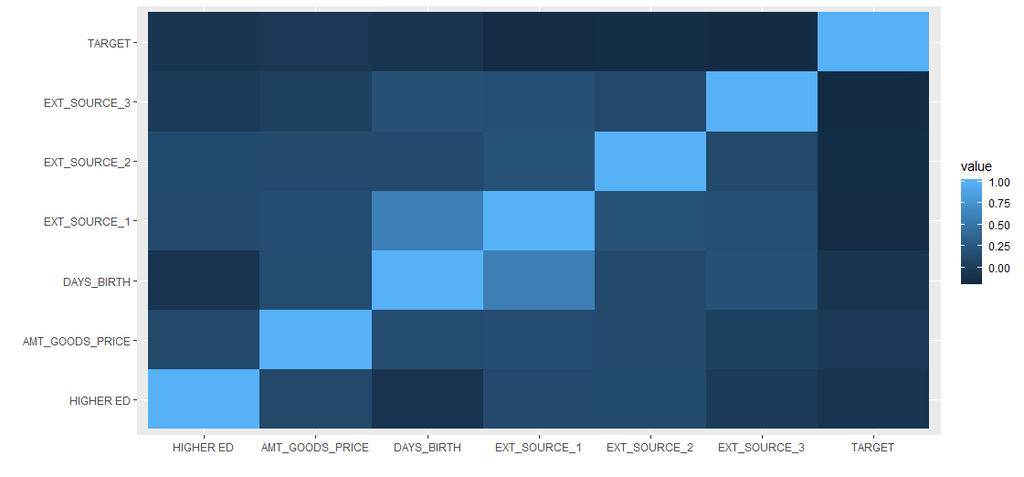

```r
heatmap <- ggplot(data=melted_cormat,aes(x=Var1, y=Var2, fill=value)) + geom_tile() +
  xlab("") + ylab("")
#print(heatmap)
```

# 8.Logistic Regression Model

There are many ways to do predictive analyses. In this case, I will use logistic regression where the dependent variable is binary 0:repaid on time and 1:payment difficulties. Ideally, we should generate many models then we choose the best logistic regression model that has the smallest accuracy measures as the base for model training.The AIC of model2 is lower.

```r
data$TARGET <- as.factor(data$TARGET)
data$TARGET <- relevel(data$TARGET, ref = "0")

model1 <- glm(TARGET~AMT_CREDIT+AMT_GOODS_PRICE+NAME_EDUCATION_TYPE+
               DAYS_BIRTH+EXT_SOURCE_1+EXT_SOURCE_2+EXT_SOURCE_3,
              family =binomial(link="logit"),data=data,
              na.action = na.omit)

summary(model1$aic)
```

```
##    Min. 1st Qu.  Median    Mean 3rd Qu.    Max.
##   50752   50752   50752   50752   50752   50752
```

```r
model2 <- glm(TARGET~AMT_CREDIT+AMT_GOODS_PRICE+DAYS_BIRTH+
               EXT_SOURCE_1+EXT_SOURCE_2+EXT_SOURCE_3+
               NAME_EDUCATION_TYPE+
               NAME_INCOME_TYPE+
               OCCUPATION_TYPE,
               family =binomial(link="logit"),
               data=data,na.action = na.omit)

summary(model2$aic)
```

```
##    Min. 1st Qu.  Median    Mean 3rd Qu.    Max.
##   50709   50709   50709   50709   50709   50709
```

```r
#model 2 is better (lower AIC)
```

# 9.Performance of Logistic Regression

We choose the model that has the lowest AIC as model for training. AUC Valid for this model is 0.74 which is quite good. We will check whether we can improve the model using other algorithm.

```r
#partition and create training data, testing data
datafix <- subset(data, select = c(
             "TARGET",
             "AMT_CREDIT",
             "AMT_GOODS_PRICE",
             "DAYS_BIRTH",
             "EXT_SOURCE_1",
             "EXT_SOURCE_2",
             "EXT_SOURCE_3",
             "NAME_EDUCATION_TYPE",
             "NAME_INCOME_TYPE",
             "OCCUPATION_TYPE"))
```

```r
set.seed(100)
train <- sample(nrow(data), 0.7*nrow(datafix))
TrainSet <- datafix[train,]
TestSet <- datafix[-train,]
```

```r
modelRL <- glm(TARGET~.,
               family =binomial(link="logit"),
               data=TrainSet,na.action = na.omit)

RL_p <- predict(modelRL, newdata = TestSet, type="response")

auc(TestSet$TARGET, RL_p)
```

```
## Area under the curve: 0.7428
```

# 10.Improving Model

First, I use Random Forest algorithm to improve the model. Using this model, we can see which variables are the most relevant. AUC Valid is not better than logistic regression. Unfortunately, my current tool can’t run the random forest using ntree >= 500 (default setting). Increasing ntree should help increase the model’s performance. Second, Xgboost also shows lower AUC Valid compared to Logistic Regression.

```r
set.seed(100)
rf <- randomForest(TARGET~., data=TrainSet, strata = TARGET,
            importance=TRUE, na.action = na.omit,
            ntree=300
            )

rf_p <- predict(rf,TestSet,type="prob")[,2]
rf_pr <- prediction(rf_p, TestSet$TARGET)

rf
```

```
##
## Call:
##  randomForest(formula = TARGET ~ ., data = TrainSet, strata = TARGET,      importance = TRUE, ntree = 300, na.action = na.omit)
##                Type of random forest: classification
##                      Number of trees: 300
## No. of variables tried at each split: 3
##
##         OOB estimate of  error rate: 7.34%
## Confusion matrix:
##       0   1 class.error
## 0 70952 175 0.002460388
## 1  5457 142 0.974638328
```

```r
print(importance(rf))
```

```
##                             0          1 MeanDecreaseAccuracy
## AMT_CREDIT          59.810548 -45.522654             58.58072
## AMT_GOODS_PRICE     59.562378 -43.222295             58.10881
## DAYS_BIRTH          79.497820 -34.919023             73.06177
## EXT_SOURCE_1        64.049337  30.607921             73.16163
## EXT_SOURCE_2         3.872229  39.974773             16.92502
## EXT_SOURCE_3         7.983979  67.765172             31.14029
## NAME_EDUCATION_TYPE 17.985347   4.764355             18.90114
## NAME_INCOME_TYPE    25.498428  -7.218595             23.37970
## OCCUPATION_TYPE     28.556848  -1.751988             26.88850
##                     MeanDecreaseGini
## AMT_CREDIT                 1231.5313
## AMT_GOODS_PRICE             940.8110
## DAYS_BIRTH                 1579.6090
## EXT_SOURCE_1               1821.2064
## EXT_SOURCE_2               1763.9157
## EXT_SOURCE_3               1712.6514
## NAME_EDUCATION_TYPE         190.9026
## NAME_INCOME_TYPE            261.7019
## OCCUPATION_TYPE             862.7551
```

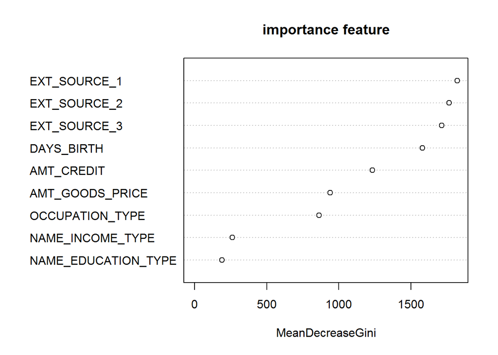

```r
varImpPlot(rf, main="importance feature",type=2)
```

```r
train <- data.matrix(TrainSet)
test <- data.matrix(TestSet)
y = data.matrix(TrainSet['TARGET'])
```

```r
xgb <- xgboost(data=train[,-1], label = y, booster = 'gbtree',
               verbose = 0,
               nrounds = 25,
               eta = 0.1,
               max_depth = 5,
               subsample = 0.5
               )

xgb_p <- predict(xgb, test[,-1])

xgb$feature_names
```

```
## [1] "AMT_CREDIT"          "AMT_GOODS_PRICE"     "DAYS_BIRTH"
## [4] "EXT_SOURCE_1"        "EXT_SOURCE_2"        "EXT_SOURCE_3"
## [7] "NAME_EDUCATION_TYPE" "NAME_INCOME_TYPE"    "OCCUPATION_TYPE"
```

[figure not shown]

```r
plot(roc(TestSet$TARGET, xgb_p, direction="<"), col="red", lwd=2, main="ROC Plot")
lines(roc(TestSet$TARGET, rf_p, direction="<"), col="purple", lwd=2)
lines(roc(TestSet$TARGET, RL_p, direction="<"), col="blue", lwd=2)
legend(0.0,0.4, c('LR','RF','XGB'),lty=c(1,1), lwd=c(2.5,2.5),col=c('red','purple','blue'))
```

```r
paste("Logistic Regression:", round(auc(TestSet$TARGET, RL_p),5))
```

```
## [1] "Logistic Regression: 0.74282"
```

```r
paste("Random Forest:", round(auc(TestSet$TARGET, rf_p),5))
```

```
## [1] "Random Forest: 0.71204"
```

```r
paste("XGBoost:", round(auc(TestSet$TARGET, xgb_p),5))
```

```
## [1] "XGBoost: 0.73241"
```